# Self organised small-world networks in brain architecture

#### By Mirjam Bruinsma, Maarten van den Ende, Nigel van Herwijnen and Thomas van der Veen

# Overview

We model one of the most complex systems: the human brain

Great number of neurons and enormous number of dendrons

# Overview

Self organised network:

- Mashed rat brains
- Kept alive in petridishes
- Small-world networks grow naturally

## Model

#### Donald Olding Hebb (1904 - 1985)

[figure not shown]

## Model

#### Ivan Petrovitsj Pavlov (1849 - 1936)

[figure not shown]

# Model

Random graph:

- Number of nodes
- Relatively high number of edges
- Assign random activation value $[-1, 1]$

# Model

Iteratively update graph:

1. Apply logistic map
2. Randomly select pivot
3. Find candidate and outcast
4. Rewire if possible

# Model

#### 1 - Apply logistic map

```
   - Each nodes activation value is updated according to the equation below
```

$$ \begin{equation*} x^i_{n+1} = (1- \epsilon) \cdot f(x^j_n)+\frac{\epsilon}{M_i}\sum_{j \in B(i)}f(x^j_n) \end{equation*} $$

```
    Where
```

$$f(x) = 1 - a x^2$$

```
    Epsilon is the coupling parameter

    a is a constant in the logistic map
```

## Model

#### 1 - Apply logistic map

[figure not shown]

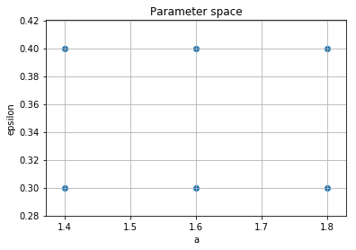

```python
plt.scatter(a,e)
plt.title("Parameter space")
plt.xlabel("a")
plt.ylabel("epsilon")
plt.grid()
plt.show()
```

# Model

#### 2 - Randomly select pivot

```
   - Randomly select one node in the network
```

# Model

#### 3 - Find candidate and outcast

- Find candidate node

> From all other units, select the one whose activation value is closest to the pivot’s.
- Find outcast node

> From all connected nodes, select the one whose activation value is furthest from the pivot's.

# Model

#### 4 - Rewire if possible

- Remove edge from pivot to outcast and place edge from pivot to candidate
- Expceptions:
  - No outcast available
  - Pivot and candidate are already connected

```python
init_notebook_mode(connected=True)
figure = build_fig()
iplot(figure, validate = False)
```

```
building figure
```

[output not shown]

## Metrics and Concepts

- Clustering Coefficient (CC)
- Phase transition
- Phase diagram

# Results

[figure not shown]

# Results

[figure not shown]

# Results

[figure not shown]

# Results

[figure not shown]

```python
plotly.tools.embed("https://plot.ly/~mirbruin/0/#/")
```

[interactive chart not shown]

#### Final network

```python
plotly.tools.embed("https://plot.ly/~maarten.w.j/672")
```

[interactive chart not shown]

## Conclusion

- Self organizing behaviour
- Effect of parameter values
- Possible phase transitions and different regimes

## Further research

- Explore phase diagram
- Explore other metrics
  - Characterictic path length
  - Modularity
- Explore larger structures
- Explore other mappings